# Relatório de análise de dados - Áreas de risco

As áreas de risco geológico foram mapeadas pelo SGB (Serviço Geológico do Brasil) em todo o território nacional. No total, são 374 municípios mapeados na região amazônica até o momento, dos quais 290 têm áreas de risco geológico.

Os municípios a serem monitorados são determinados pelo governo federal, conforme diretrizes estabelecidas pela Lei 12.608/2012, ou a pedido da Defesa Civil, e concentram a maioria dos desastres naturais, devido a riscos hidrogeológicos, envolvendo edificações.

As áreas são identificadas a partir de mapas, imagens de satélite e trabalho em campo, em parceria com a Defesa Civil, prefeitura ou outra entidade local. Os polígonos são determinados pela equipe *in loco*, a partir de informações como as características morfológicas do terreno, sinais de movimentação e instabilidade nas encostas e taludes, análise de vulnerabilidade de construção das moradias, presença de corpos d’água e recorrência dos eventos hidrológicos, histórico da ocorrência de eventos geológicos no local, etc.

Os tipos de risco identificado pela equipe do SGB e sua classificação no código brasileiro de desastre são:

| tipolo_g1 | cobrade_01 |
| --- | --- |
| Queda | 1.1.3.1.1 |
| Deslizamento | 1.1.3.2.1 |
| Erosão | 1.1.3.2.1 |
| Corrida de massa | 1.1.3.3.1 |
| Deslizamento | 1.1.3.3.1 |
| Colapso | 1.1.3.4.0 |
| Subsidência | 1.1.3.4.0 |
| Deslizamento | 1.1.3.4.0 |
| Erosão | 1.1.4.1.0 |
| Erosão | 1.1.4.2.0 |
| Erosão | 1.1.4.3.1 |
| Erosão | 1.1.4.3.2 |
| Erosão | 1.1.4.3.3 |
| Enchente | 1.2.1.0.0 |
| Inundação | 1.2.1.0.0 |
| Enxurrada | 1.2.2.0.0 |
| Alagamento | 1.2.3.0.0 |
| Rastejo | NA |
| Erosão | NA |
| Inundação | NA |
| Deslizamento | NA |

- Alagamento (hidrológico)
- Colapso (geológico)
- Corrida de massa (geológico)
- Deslizamento (geológico)
- Enchente (hidrológico)
- Enxurrada (hidrológico)
- Erosão (geológico)
- Inundação (hidrológico)
- Queda (geológico)
- Rastejo (geológico)
- Subsidência (geológico)

Referências:

- [Entenda a diferença entre os tipos de desastres naturais e tecnológicos registrados no Brasil](https://www.gov.br/mdr/pt-br/ultimas-noticias/entenda-a-diferenca-entre-os-tipos-de-desastres-naturais-e-tecnologicos-registrados-no-brasil)
- [Classificação de desastres: brasileira (COBRADE) e internacional](https://escriba.ipt.br/pdf/175230.pdf)

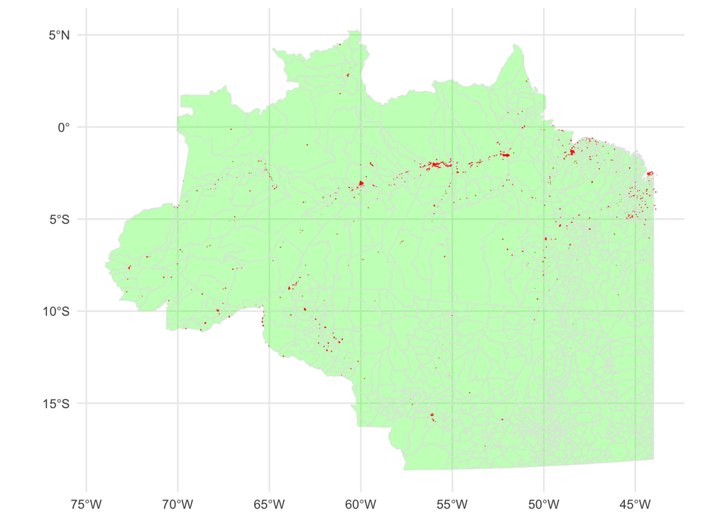

Figura 1: Áreas de risco na Amazônia

## Áreas de risco têm maior prevalência em setores urbanos

As regiões mapeadas, em sua maioria urbanas, são classificadas como risco **alto** ou **muito alto**, a depender do nível de gravidade e urgência da situação.

Apesar de 64% dos setores censitários nos 290 municípios monitorados serem considerados urbanos, o percentual de setores urbanos em áreas de risco é significativamente maior: 89% (Tabela 1).

Tabela 1: Classificação do IBGE dos setores censitários impactados por áreas de risco e classificação geral dos setores de municípios monitorados, desconsiderando informação de risco

| Classificação | Alto | Muito alto | Alto + Muito alto | Classificação geral |
| --- | --- | --- | --- | --- |
| Urbana | 3142 (88.2%) | 1922 (89.4%) | 5064 (88.6%) | 25277 (64%) |
| Rural | 374 (10.5%) | 205 (9.5%) | 579 (10.1%) | 14189 (36%) |
| NA | 46 (1.3%) | 24 (1.1%) | 70 (1.2%) | 57 (0%) |

As áreas de risco foram analisadas a partir do cruzamento espacial dos dados com os setores censitários do Censo 2022. As informações do censo que foram analisadas são:

- Tipo de domicílio
- Tipo de setor censitário
- Acesso a rede de esgoto
- Coleta de lixo
- Pessoas alfabetizadas
- Faixa etária
- Cor ou raça
- Gênero da pessoa responsável pelo domicílio

O total de pessoas afetadas em áreas de risco é uma **estimativa** a partir da proporção equivalente que a área de risco ocupa dos setores censitários. Por exemplo, se uma área de risco ocupa 10% da área de um setor censitário com 20 pessoas, é considerado neste caso que 2 pessoas estão nessa área de risco.

## Perfil das áreas de risco

Na Amazônia Legal, cerca de 619 240 pessoas vivem em áreas consideradas de risco. Dessas, 61% estão em áreas de risco **alto** e 39% estão em áreas de risco **muito alto**.

Dos 374 municípios mapeados na região amazônica, a maioria está no Pará (PA), com 96 municípios setorizados. No entanto, os estados do Acre (AC), Amazonas (AM) e Rondônia (RO) tiveram 100% de seus municípios analisados (Tabela 2). Apesar disso, apenas 290 municípios apresentaram setores de risco; nos 84 municípios restantes, não foram identificadas áreas de risco pelo SGB.

Tabela 2: Quantidade de municípios mapeados por UF

| uf | n | total | pct |
| --- | --- | --- | --- |
| TO | 15 | 139 | 11% |
| MT | 22 | 141 | 15% |
| RR | 5 | 15 | 33% |
| MA | 92 | 217 | 42% |
| AP | 8 | 16 | 50% |
| PA | 96 | 144 | 67% |
| AC | 22 | 22 | 100% |
| RO | 52 | 52 | 100% |
| AM | 62 | 62 | 100% |

## População em risco nos 290 municípios monitorados

- 3,3 % da população em municípios monitorados da Amazônia Legal estão em áreas de risco
- A proporção é maior no Acre (6%) e Amapá (5,7%)

Tabela 3: População em risco por UF

| UF | População total nos locais mapeados | População em risco | % da população emr isco |
| --- | --- | --- | --- |
| TO | 273 104 | 871 | 0.3% |
| MT | 1 595 588 | 4 857 | 0.3% |
| RR | 453 748 | 13 300 | 2.9% |
| AP | 644 929 | 36 498 | 5.7% |
| RO | 1 349 046 | 39 435 | 2.9% |
| AC | 773 394 | 47 337 | 6.1% |
| MA | 3 542 085 | 103 399 | 2.9% |
| AM | 3 794 489 | 116 292 | 3.1% |
| PA | 6 391 670 | 257 252 | 4.0% |
| Total | 18 818 053 | 619 241 | 3.3% |

## Perfil demográfico

- 68% das pessoas em áreas de risco são alfabetizadas
- A maioria das pessoas responsáveis por domicílios em áreas de risco são mulheres (55%) (Tabela 7)
- 69% da população em risco é parda (Tabela 4)

Tabela 4: População em risco por cor ou raça

| Cor | Estimativa população em risco | % |
| --- | --- | --- |
| parda | 126 279 | 69.0% |
| branca | 32 211 | 17.6% |
| preta | 23 293 | 12.7% |
| indígena | 1 137 | 0.6% |
| amarela | 68 | 0.0% |

- Mais de um terço da população tem até 19 anos (34%), e 51% de quem vive nessas áreas tem menos de 30 anos (Tabela 5)
- Em Roraima, a população é ainda mais jovem: 32% das pessoas em áreas de risco têm até 14 anos

Tabela 5: População em risco por faixa etária

| Faixa etária | Estimativa população em risco | % | % acumulado |
| --- | --- | --- | --- |
| 0 a 4 anos | 48 861 | 7.9% | 7.9% |
| 5 a 9 anos | 52 260 | 8.4% | 16.3% |
| 10 a 14 anos | 53 278 | 8.6% | 24.9% |
| 15 a 19 anos | 57 871 | 9.4% | 34.3% |
| 20 a 24 anos | 56 417 | 9.1% | 43.4% |
| 25 a 29 anos | 50 175 | 8.1% | 51.5% |
| 30 a 39 anos | 95 150 | 15.4% | 66.9% |
| 40 a 49 anos | 82 727 | 13.4% | 80.3% |
| 50 a 59 anos | 57 227 | 9.2% | 89.5% |
| 60 a 69 anos | 37 360 | 6.0% | 95.5% |
| 70 anos ou mais | 27 567 | 4.5% | 100.0% |

Tabela 6: População em risco por faixa etária

| Faixa etária | AC | AM | AP | MA | MT | PA | RO | RR | TO |
| --- | --- | --- | --- | --- | --- | --- | --- | --- | --- |
| 0 a 4 anos | 4277 (9% - ac. 9%) | 11073 (10% - ac. 10%) | 3463 (9% - ac. 9%) | 7308 (7% - ac. 7%) | 326 (7% - ac. 7%) | 18109 (7% - ac. 7%) | 2841 (7% - ac. 7%) | 1399 (11% - ac. 11%) | 64 (7% - ac. 7%) |
| 5 a 9 anos | 4384 (9% - ac. 18%) | 11634 (10% - ac. 20%) | 3521 (10% - ac. 19%) | 8107 (8% - ac. 15%) | 354 (7% - ac. 14%) | 19790 (8% - ac. 15%) | 2944 (7% - ac. 15%) | 1450 (11% - ac. 22%) | 77 (9% - ac. 16%) |
| 10 a 14 anos | 4385 (9% - ac. 28%) | 11177 (10% - ac. 29%) | 3446 (9% - ac. 29%) | 8905 (9% - ac. 24%) | 315 (6% - ac. 20%) | 20720 (8% - ac. 23%) | 2941 (7% - ac. 22%) | 1317 (10% - ac. 32%) | 71 (8% - ac. 24%) |
| 15 a 19 anos | 4839 (10% - ac. 38%) | 11842 (10% - ac. 39%) | 3727 (10% - ac. 39%) | 9727 (9% - ac. 33%) | 386 (8% - ac. 28%) | 22812 (9% - ac. 32%) | 3222 (8% - ac. 30%) | 1233 (9% - ac. 41%) | 82 (9% - ac. 34%) |
| 20 a 24 anos | 4721 (10% - ac. 48%) | 11290 (10% - ac. 49%) | 3723 (10% - ac. 49%) | 8850 (9% - ac. 42%) | 400 (8% - ac. 37%) | 22880 (9% - ac. 41%) | 3366 (9% - ac. 39%) | 1123 (9% - ac. 49%) | 64 (7% - ac. 41%) |
| 25 a 29 anos | 4049 (9% - ac. 56%) | 10024 (9% - ac. 58%) | 3115 (9% - ac. 58%) | 7507 (7% - ac. 49%) | 386 (8% - ac. 45%) | 20872 (8% - ac. 49%) | 3151 (8% - ac. 47%) | 1012 (8% - ac. 57%) | 58 (7% - ac. 48%) |
| 30 a 39 anos | 6742 (14% - ac. 71%) | 17221 (15% - ac. 72%) | 5263 (14% - ac. 72%) | 15882 (15% - ac. 64%) | 723 (15% - ac. 60%) | 41222 (16% - ac. 65%) | 6017 (15% - ac. 62%) | 1960 (15% - ac. 72%) | 120 (14% - ac. 62%) |
| 40 a 49 anos | 5666 (12% - ac. 83%) | 14094 (12% - ac. 85%) | 4374 (12% - ac. 84%) | 13660 (13% - ac. 77%) | 701 (14% - ac. 74%) | 36847 (14% - ac. 79%) | 5669 (14% - ac. 76%) | 1589 (12% - ac. 84%) | 126 (15% - ac. 76%) |
| 50 a 59 anos | 3592 (8% - ac. 90%) | 8892 (8% - ac. 92%) | 2943 (8% - ac. 92%) | 9902 (10% - ac. 87%) | 587 (12% - ac. 86%) | 25757 (10% - ac. 89%) | 4402 (11% - ac. 88%) | 1064 (8% - ac. 92%) | 88 (10% - ac. 86%) |
| 60 a 69 anos | 2482 (5% - ac. 95%) | 5360 (5% - ac. 97%) | 1716 (5% - ac. 97%) | 7235 (7% - ac. 94%) | 413 (9% - ac. 95%) | 16593 (6% - ac. 95%) | 2869 (7% - ac. 95%) | 625 (5% - ac. 97%) | 66 (8% - ac. 94%) |
| 70 anos ou mais | 2185 (5% - ac. 100%) | 3643 (3% - ac. 100%) | 1197 (3% - ac. 100%) | 6224 (6% - ac. 100%) | 265 (5% - ac. 100%) | 11599 (5% - ac. 100%) | 1993 (5% - ac. 100%) | 409 (3% - ac. 100%) | 54 (6% - ac. 100%) |

Tabela 7: População em risco por gênero

| Gênero | Estimativa população em risco | % |
| --- | --- | --- |
| M | 82 484 | 45.1% |
| F | 100 504 | 54.9% |

## Tipo de domicílio e classificação dos setores censitários

- A grande maioria dos domicílios em áreas de risco (93%) são casas (Tabela 8)
- Fora dos setores censitários considerados “Não especiais”, a população em risco se concentra (45%) em favelas e comunidades urbanas (Tabela 9)
- Essa proporção aumenta para áreas de risco **muito alto**: 61% (147 mil pessoas) de quem está nessas áreas vive em favelas
- 34% das pessoas residentes em áreas de risco **alto** moram em favelas e comunidades urbanas

Segundo o IBGE, favelas e comunidades urbanas são áreas com predominância de domicílios em ocupações informais (domicílios que não têm sua propriedade formalizada através de escritura ou outro instrumento jurídico equivalente). Além disso, incluem pelo menos um dos demais critérios: ausência ou oferta incompleta de serviços públicos; predomínio de edificações, arruamento e infraestrutura que usualmente são autoproduzidos ou se orientam por parâmetros urbanísticos e construtivos distintos dos definidos pelos órgãos públicos; localização em áreas com restrição à ocupação definidas pela legislação ambiental ou urbanística (ocupações irregulares em reservas ambientais ou outras áreas restritas, como encostas inseguras, vias públicas, margens de rios ou outras áreas impróprias para residências).

Tabela 8: Áreas em risco por tipo de domicílio

| Tipo de domicílio | Estimativa domicílios em risco | % |
| --- | --- | --- |
| casa | 170 756 | 92.9% |
| condomínio | 6 328 | 3.4% |
| apartamento | 5 353 | 2.9% |
| cortiço | 708 | 0.4% |
| pensão | 168 | 0.1% |
| barraca | 106 | 0.1% |

Tabela 9: População em risco por tipo de setor censitário

| Tipo de setor | Estimativa população em risco | % |
| --- | --- | --- |
| Não especial | 340 253 | 54.9% |
| Favela e Comunidade Urbana | 276 560 | 44.7% |
| Agrupamento indígena | 1 182 | 0.2% |
| Agrupamento quilombola | 928 | 0.1% |
| Alojamento / acampamento | 168 | 0.0% |
| Unidade prisional | 73 | 0.0% |
| Setor com baixo patamar domiciliar | 71 | 0.0% |
| Agrovila do PA | 3 | 0.0% |
| Convento / hospital / ILPI / IACA | 2 | 0.0% |
| Quartel e base militar | 0 | 0.0% |

### Outras regiões

Em municípios monitorados pelo SGB fora da Amazônia Legal, a população em áreas de risco estão concentradas também em favelas e comunidades urbanas, mas numa proporção menor.

- Na Amazônia, 45% da população em risco vive em favelas e comunidades urbanas
- Fora da Amazônia, essa taxa é de 22% (Tabela 10)
- Mesmo em áreas de risco muito alto, a proporção em favelas é de 24% (Tabela 11)

Tabela 10: População em risco por tipo de setor censitário fora da Amazônia

| Tipo de setor | Estimativa população em risco | % |
| --- | --- | --- |
| Não especial | 1 897 377 | 77.5% |
| Favela e Comunidade Urbana | 537 197 | 21.9% |
| Agrupamento quilombola | 10 464 | 0.4% |
| Agrupamento indígena | 1 498 | 0.1% |
| Agrovila do PA | 497 | 0.0% |
| Unidade prisional | 413 | 0.0% |
| Setor com baixo patamar domiciliar | 319 | 0.0% |
| Convento / hospital / ILPI / IACA | 261 | 0.0% |
| Alojamento / acampamento | 7 | 0.0% |
| Quartel e base militar | 1 | 0.0% |

Tabela 11: População fora da Amazônia por grau de risco e tipo de setor censitário

| Tipo de setor | Estimativa população em risco alto | Estimativa população em risco muito alto |
| --- | --- | --- |
| Não especial | 1 290 916 (78.8%) | 606 461.9 (74.9%) |
| Favela e Comunidade Urbana | 340 122 (20.8%) | 197 075.6 (24.3%) |
| Agrupamento quilombola | 5 669 (0.3%) | 4 795.3 (0.6%) |
| Agrupamento indígena | 567 (0.0%) | 931.0 (0.1%) |
| Agrovila do PA | 483 (0.0%) | 14.4 (0.0%) |
| Setor com baixo patamar domiciliar | 254 (0.0%) | 65.1 (0.0%) |
| Unidade prisional | 233 (0.0%) | 180.7 (0.0%) |
| Convento / hospital / ILPI / IACA | 171 (0.0%) | 89.9 (0.0%) |
| Alojamento / acampamento | 0 (0.0%) | 7.1 (0.0%) |
| Quartel e base militar | 0 (0.0%) | 0.8 (0.0%) |

## Acesso à rede de esgoto

- Mais de um terço (35%) dos domicílios em área de risco destina o esgoto em fossa rudimentar ou buraco
- Apenas 17,8% dos domicílios nessas áreas têm acesso à rede geral ou pluvial. Outros 7% têm acesso à rede via fossa séptica ou fossa filtro

Tabela 12: Domicílios em risco por tipo de esgoto

| Condição de acesso à rede de esgoto | Estimativa domicílios em risco | % |
| --- | --- | --- |
| fossa rudimentar ou buraco | 64 396 | 35.4% |
| fossa séptica ou fossa filtro não ligada à rede | 42 985 | 23.6% |
| rede geral ou pluvial | 32 466 | 17.8% |
| rio, lago, córrego ou mar | 16 082 | 8.8% |
| fossa séptica ou fossa filtro ligada à rede | 12 506 | 6.9% |
| vala | 11 038 | 6.1% |
| outra forma | 1 958 | 1.1% |
| inexistente, pois não tinham banheiro nem sanitário | 613 | 0.3% |

### Outras regiões

Em municípios localizados em regiões fora da Amazônia Legal, o acesso à rede de esgoto em áreas de risco é bastante diferente: 63% dos domicílios em risco possuem acesso a rede geral ou puvial.

Tabela 13: Domicílios em risco por tipo de esgoto, em áreas fora da Amazônia Legal

| Condição de acesso à rede de esgoto | Estimativa domicílios em risco | % |
| --- | --- | --- |
| rede geral ou pluvial | 552 154 | 63.4% |
| fossa séptica ou fossa filtro não ligada à rede | 92 109 | 10.6% |
| fossa rudimentar ou buraco | 79 900 | 9.2% |
| fossa séptica ou fossa filtro ligada à rede | 69 189 | 7.9% |
| rio, lago, córrego ou mar | 56 364 | 6.5% |
| vala | 16 825 | 1.9% |
| outra forma | 3 639 | 0.4% |
| inexistente, pois não tinham banheiro nem sanitário | 612 | 0.1% |

## Coleta de lixo

- A maior parte das moradias em áreas de risco tem acesso à coleta de lixo regular, mas uma parcela significativa ainda depende de métodos alternativos ou inadequados, como descarte em terrenos baldios ou queima (Tabela 14)
- A proporção de pessoas em risco sem acesso à coleta adequada de lixo reflete desigualdades no fornecimento de serviços básicos em áreas vulneráveis.

Tabela 14: População em risco por tipo de coleta de lixo

| Condição de coleta de lixo | Estimativa domicílios em risco | % |
| --- | --- | --- |
| Lixo coletado no domicílio por serviço de limpeza | 155 222 | 85.2% |
| Lixo depositado em caçamba de serviço de limpeza | 16 641 | 9.1% |
| Lixo queimado na propriedade | 7 119 | 3.9% |
| Lixo jogado em terreno baldio, encosta ou área pública | 3 078 | 1.7% |
| Lixo enterrado na propriedade | 39 | 0.0% |

### Outras regiões

Fora da Amazônia Legal, outras áreas mapeadas têm diferenças em relação à destinação do lixo, mas não tão constratante quanto o acesso à rede de esgoto. A proporção de domicílios que queimam o lixo na propriedade na Amazônia é maior, mas ainda assim é pequena comparado com a quantidade de pessoas que possuem coleta domiciliar.

Tabela 15: Domicílios em risco por tipo de coleta de lixo, em áreas fora da Amazônia Legal

| Condição de coleta de lixo | Estimativa domicílios em risco | % |
| --- | --- | --- |
| Lixo coletado no domicílio por serviço de limpeza | 765 315 | 87.7% |
| Lixo depositado em caçamba de serviço de limpeza | 94 966 | 10.9% |
| Lixo queimado na propriedade | 6 528 | 0.7% |
| Lixo jogado em terreno baldio, encosta ou área pública | 6 010 | 0.7% |
| Lixo enterrado na propriedade | 86 | 0.0% |

## Locais destacados

No Pará, estado com o maior número de municípios mapeados pelo SGB, cerca de 257 mil pessoas vivem em áreas consideradas de risco. No entanto, percentualmente a situação é mais grave no Acre e Amapá, onde cerca de 6% da população vive em locais de risco alto ou muito alto.

Tabela 16: Pessoas em áreas de risco por UF

| uf | Alto | Muito alto | total | total_pessoas | pct |
| --- | --- | --- | --- | --- | --- |
| PA | 88 202 | 169 050 | 257 252 | 6 391 670 | 4.0% |
| AM | 83 228 | 33 063 | 116 292 | 3 794 489 | 3.1% |
| MA | 79 690 | 23 709 | 103 399 | 3 542 085 | 2.9% |
| AC | 41 982 | 5 355 | 47 337 | 773 394 | 6.1% |
| RO | 35 706 | 3 729 | 39 435 | 1 349 046 | 2.9% |
| AP | 35 573 | 925 | 36 498 | 644 929 | 5.7% |
| RR | 11 052 | 2 247 | 13 300 | 453 748 | 2.9% |
| MT | 3 488 | 1 369 | 4 857 | 1 595 588 | 0.3% |
| TO | 868 | 2 | 871 | 273 104 | 0.3% |

### Municípios com mais pessoas em risco

- Proporcionalmente, Vitória do Jari (AP) é o município com mais pessoas em risco: são mais de 6 mil pessoas em situação de risco alto, representando 53% da população
- Em número absoluto de pessoas, moradores de Belém (PA) são os mais afetados, com mais de 129 mil pessoas (10% da população) vivendo em áreas de risco alto ou muito alto

Tabela 17: 10 municípios com maior % de moradores em risco

| municipio | uf | Alto | Muito alto | total_risco | total_pessoas | pct_risco |
| --- | --- | --- | --- | --- | --- | --- |
| Vitória do Jari | AP | 6 018 | 0 | 6 018 | 11 291 | 53% |
| Caracaraí | RR | 9 619 | 0 | 9 619 | 20 957 | 46% |
| Tarauacá | AC | 11 674 | 214 | 11 888 | 43 467 | 27% |
| Anamã | AM | 2 545 | 4 | 2 549 | 9 962 | 26% |
| Vitória do Mearim | MA | 0 | 7 165 | 7 165 | 30 805 | 23% |
| Eirunepé | AM | 7 695 | 0 | 7 695 | 33 170 | 23% |
| Laranjal do Jari | AP | 7 713 | 20 | 7 732 | 35 114 | 22% |
| Trizidela do Vale | MA | 4 683 | 0 | 4 683 | 22 484 | 21% |
| Boca do Acre | AM | 0 | 6 640 | 6 640 | 35 447 | 19% |
| Itamarati | AM | 1 780 | 147 | 1 927 | 10 937 | 18% |

Tabela 18: 10 municípios com maior número de moradores em risco

| municipio | uf | Alto | Muito alto | total_risco | total_pessoas | pct_risco |
| --- | --- | --- | --- | --- | --- | --- |
| Belém | PA | 3 240 | 126 398 | 129 637 | 1 303 403 | 10% |
| Manaus | AM | 41 233 | 7 106 | 48 339 | 2 063 689 | 2% |
| Marabá | PA | 28 646 | 0 | 28 646 | 266 533 | 11% |
| Codó | MA | 19 750 | 0 | 19 750 | 114 275 | 17% |
| Santana | AP | 18 006 | 0 | 18 006 | 107 618 | 17% |
| Porto Velho | RO | 8 606 | 3 428 | 12 034 | 460 434 | 3% |
| Parauapebas | PA | 7 227 | 4 783 | 12 010 | 267 836 | 4% |
| Tarauacá | AC | 11 674 | 214 | 11 888 | 43 467 | 27% |
| Rio Branco | AC | 9 966 | 617 | 10 583 | 364 756 | 3% |
| Abaetetuba | PA | 9 686 | 333 | 10 019 | 158 188 | 6% |

### Municípios com mais de 90% das pessoas em risco em favelas

| Município | UF | Tipo setor | Pessoas afetadas | % |
| --- | --- | --- | --- | --- |
| Lábrea | AM | Favela e Comunidade Urbana | 269 | 100.0% |
| Manaus | AM | Favela e Comunidade Urbana | 44 126 | 91.3% |
| Ananindeua | PA | Favela e Comunidade Urbana | 6 508 | 98.2% |
| Vitória do Jari | AP | Favela e Comunidade Urbana | 5 997 | 99.7% |

#### Lábrea (AM): risco de erosão e inundação

**Lábrea (AM)** tem uma diferença muito grande em relação ao acesso à rede de esgoto entre a população que mora dentro e fora de áreas de risco. Em áreas de risco, o destino do esgoto de cerca de 60% da população é em rio, lago ou córrego. Em outras regiões sem risco, essa proporção é de 12%.

O acesso à rede de esgoto é possível para 28% da população de Lábrea que não está nas áreas de risco alto ou muito alto. Dentro dessas áreas, são menos de 9%.

Tabela 19: Tipos de risco em Lábrea

| tipolo_g1 | tipolo_e1 | cobrade_01 | tipolo_g2 | cobrade_02 | grau_risco | pessoas |
| --- | --- | --- | --- | --- | --- | --- |
| Erosão | Terras caídas | 1.1.4.2.0 | Inundação | 1.2.1.0.0 | Alto | 538 |

#### Vitória do Jari (AP): risco de inundação em domicílios chefiados por mulheres

- Mulheres chefiam 56% dos lares em áreas de risco na cidade de Vitória do Jari
- Em setores da cidade sem áreas de risco, essa taxa é de 24%
- As áreas mapeadas no município têm risco de inundação

Tabela 20: Tipos de risco em Vitória do Jari

| tipolo_g1 | cobrade_01 | grau_risco | pessoas |
| --- | --- | --- | --- |
| Inundação | 1.2.1.0.0 | Alto | 12 035 |

Tabela 21: 56% dos domicílios em áreas de risco são comandado por mulheres

| genero | n | pct |
| --- | --- | --- |
| M | 705 | 44% |
| F | 897 | 56% |

#### Ananindeua (PA): inundação, erosão, deslizamento

Tabela 22: Tipos de risco em Ananindeua

| tipolo_g1 | tipolo_e1 | cobrade_01 | tipolo_g2 | cobrade_02 | grau_risco | pessoas |
| --- | --- | --- | --- | --- | --- | --- |
| Erosão | Ravina | 1.1.4.3.2 | Alagamento | 1.2.3.0.0 | Muito alto | 164 |
| Alagamento | NA | 1.2.3.0.0 | NA | NA | Muito alto | 1 399 |
| Inundação | NA | 1.2.1.0.0 | NA | NA | Muito alto | 23 163 |
| Alagamento | NA | 1.2.3.0.0 | NA | NA | Alto | 1 010 |
| Erosão | Ravina | 1.1.4.3.2 | NA | NA | Muito alto | 164 |
| Inundação | NA | 1.2.1.0.0 | Alagamento | 1.2.3.0.0 | Alto | 20 |
| Inundação | NA | 1.2.1.0.0 | Alagamento | 1.2.3.0.0 | Muito alto | 121 605 |
| Erosão | NA | NA | NA | NA | Muito alto | 82 |
| Erosão | Erosão costeira/marinha | 1.1.4.1.0 | Deslizamento | 1.1.3.2.1 | Muito alto | 82 |
| Erosão | Erosão costeira/marinha | 1.1.4.1.0 | NA | NA | Alto | 0 |
| Inundação | NA | 1.2.1.0.0 | Erosão | 1.1.4.1.0 | Muito alto | 5 791 |
| Deslizamento | Deslizamento planar | 1.1.3.2.1 | NA | NA | Alto | 46 |

- 10 setores censitários afetados, dos quais 6 são agrupamentos indígenas
- Os cerca de 215 indígenas em áreas de risco estão divididos em área rural (13%) e urbana (87%)
- Todas as áreas de risco mapeadas em Tabatinga estão sob risco de erosão e deslizamento devido a terras caídas

Tabela 23: Tipos de risco em Tabatinga

| tipolo_g1 | tipolo_e1 | cobrade_01 | tipolo_g2 | cobrade_02 | grau_risco | pessoas |
| --- | --- | --- | --- | --- | --- | --- |
| Erosão | Erosão de margem fluvial | 1.1.4.2.0 | Deslizamento | 1.1.3.2.1 | Muito alto | 229 |
| Erosão | Erosão de margem fluvial | 1.1.4.2.0 | Deslizamento | 1.1.3.2.1 | Alto | 203 |

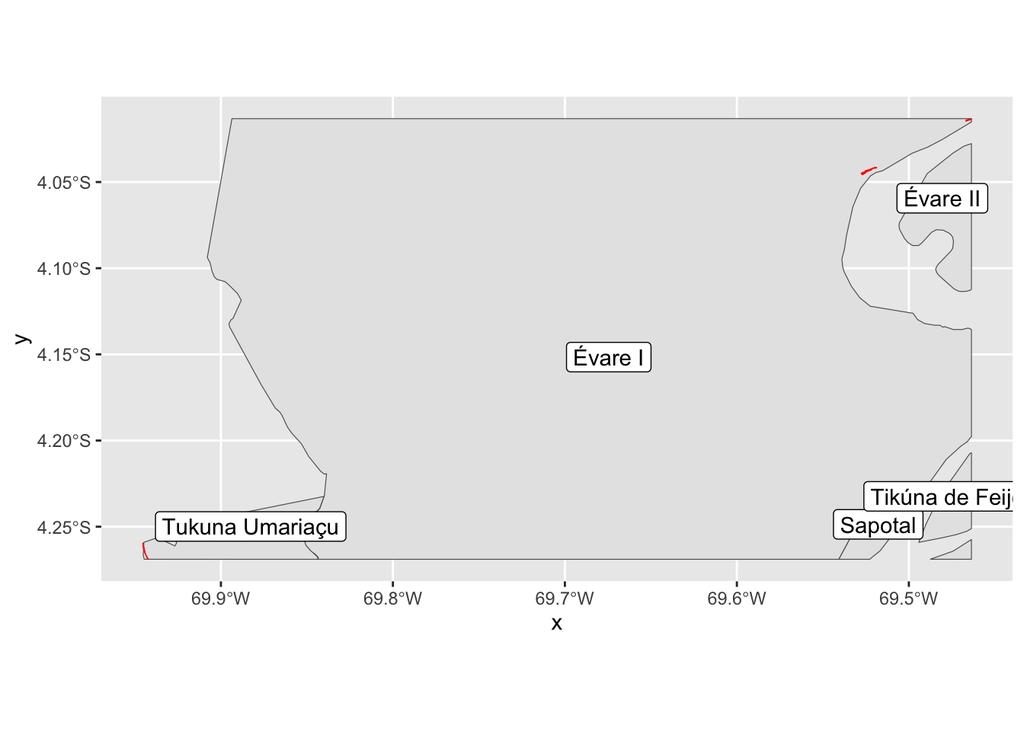

Figura 2: TIs em Tabatinga (AM) em locais de risco - Évare I e Tukuna Umariaçu

Tabela 24: Indígenas em áreas de risco em Tabatinga (AM)

| SITUACAO | pessoas | pct |
| --- | --- | --- |
| Urbana | 187 | 86.8% |
| Rural | 28 | 13.2% |
| Total | 215 | 100.0% |

### Principais capitais: Belém e Manaus

#### Belém

- O maior risco em Belém é de inundação: 89% das pessoas em áreas de risco estão sujeitas a inundação
- No total, são cerca de 129 mil pessoas em áreas de risco alto ou muito alto em Belém

Tabela 25: Tipos de risco em Belém

| tipolo_g1 | pessoas | pct |
| --- | --- | --- |
| Inundação | 115 576 | 89% |
| Alagamento | 14 031 | 11% |
| Erosão | 31 | 0% |
| Total | 129 637 | 100% |

#### Manaus (AM)

- Em Manaus, 91% das pessoas em áreas de risco (cerca de 44 mil) estão sujeitas a deslizamentos
- As outras pessoas em áreas de risco estão sujeitas a inundações

Tabela 26: Tipos de risco em Manaus

| tipolo_g1 | pessoas | pct |
| --- | --- | --- |
| Deslizamento | 44 130 | 91% |
| Inundação | 4 209 | 9% |

##### Esgoto e Lixo

- Cerca de um 29% dos moradores de áreas consideradas com risco geológico alto e muito alto têm acesso à rede geral de esgoto. Em setores que não possuem áreas de risco, essa proporção é de mais de 53%
- Mais de 13 mil pessoas (28%) em área de risco utilizam fossa rudimentar ou buraco. Nos setores sem áreas de risco, apenas 16%
- No geral, pessoas em áreas de risco têm coleta de lixo no domicílio (87%), apesar de ser uma taxa inferior aos setores sem áreas de risco (92%)

##### Alfabetização

- Em áreas de risco alto e muito alto, a taxa de alfabetização gira em torno de 68%.
- Fora dessas regiões, a taxa é de 74%

##### Cor

- Em locais com risco alto ou muito alto, a prevalência de pessoas brancas é relativamente menor: 16% contra 24% em setores sem risco
- A proporção de pessoas pardas e pretas é maior em áreas de risco

##### Idade

- As pessoas que moram em áreas de risco tendem a ser mais jovens: 29% são crianças de até 14 anos
- Esse é o maior percentual entre as capitais

##### Gênero

- Mais de metade (56%) dos domicílios em áreas de risco alto e muito alto são comandados por mulheres
- Essa taxa é um pouco menor em setores sem áreas de risco: 53%

##### Pior setor

- O setor censitário com piores índices fica no Loteamento João Paulo, no bairro Jorge Teixeira
- Praticamente metade do setor (48%) é classificado como área de risco alto ou muito alto, com risco de deslizamento
- Segundo o Censo 2022, 255 pessoas moram na região, em casas
- Destinação do esgoto do banheiro ou sanitário ou buraco para dejeções é fossa rudimentar ou buraco
- Na maior parte dos casos, o lixo é depositado em caçamba ou jogado em terreno baldio, encosta ou área pública
- Mais de um terço das pessoas não são alfabetizadas (36%)

##### Observações

- Em áreas de risco, a população é estimada de forma proporcional à porcentagem que a área de risco ocupa sobre os setores censitários
- Fora das áreas de risco, foram usados os dados dos setores inteiros, considerando somente os setores sem nenhuma sobreposição com áreas de risco
- Para encontrar o pior setor, todos os setores com alguma área de risco muito alto foram agrupados por proximidade dos valores de todas as variáveis envolvidas (k-médias). O pior setor foi escolhido como aquele que se encontrava entre os cinco primeiros para os seguintes recortes:
  - menor taxa de coleta de lixo em domicílio
  - menor taxa de acesso à rede de esgoto
  - menor taxa de alfabetização entre jovens

## Rondônia (100% mapeado)

Tabela 27: Tipologia dos principais riscos em municípios rondonenses

| tipolo_g1 | tipolo_e1 | cobrade_01 | n | pct |
| --- | --- | --- | --- | --- |
| Erosão | NA | NA | 5.3 | 0.0% |
| Queda | Queda de blocos | 1.1.3.1.1 | 19.9 | 0.0% |
| Erosão | Voçoroca | 1.1.4.3.3 | 63.5 | 0.0% |
| Alagamento | NA | 1.2.3.0.0 | 548.3 | 0.2% |
| Erosão | Erosão laminar | 1.1.4.3.1 | 774.7 | 0.3% |
| Erosão | Ravina | 1.1.4.3.2 | 782.7 | 0.3% |
| Deslizamento | Deslizamento planar | 1.1.3.2.1 | 835.4 | 0.3% |
| Deslizamento | Deslizamento não especificado | 1.1.3.2.1 | 1 130.6 | 0.4% |
| Erosão | Erosão de margem fluvial | 1.1.4.2.0 | 19 957.9 | 7.1% |
| Enchente | NA | 1.2.1.0.0 | 65 204.9 | 23.1% |
| Inundação | NA | 1.2.1.0.0 | 193 370.3 | 68.4% |

Tabela 28: Domicílios em áreas de risco por gênero em RO

| genero | n_risco | pct_risco | n_geral | pct_geral |
| --- | --- | --- | --- | --- |
| M | 7 114 | 52.5% | 253 127 | 54.2% |
| F | 6 443 | 47.5% | 213 914 | 45.8% |

Praticamente metade (47%) dos domicílios em regiões consideradas de risco em Rodônia destinam o esgoto em fossa rudimentar ou buraco (Tabela 29), similar à situação geral do estado: mesmo em setores sem áreas de risco, a principal destinação do esgoto é essa (Tabela 30).

Tabela 29: Esgoto em áreas de risco em Rondônia

| Condição de acesso à rede de esgoto | Estimativa domicílios em risco | % |
| --- | --- | --- |
| fossa rudimentar ou buraco | 6 413 | 47.3% |
| fossa séptica ou fossa filtro não ligada à rede | 3 927 | 29.0% |
| rede geral ou pluvial | 2 161 | 15.9% |
| vala | 385 | 2.8% |
| fossa séptica ou fossa filtro ligada à rede | 350 | 2.6% |
| rio, lago, córrego ou mar | 252 | 1.9% |
| outra forma | 60 | 0.4% |
| inexistente, pois não tinham banheiro nem sanitário | 6 | 0.0% |

Tabela 30: Esgoto em setores censitários sem áreas de risco em Rondônia

| Condição de acesso à rede de esgoto | Estimativa domicílios em risco | % |
| --- | --- | --- |
| fossa rudimentar ou buraco | 204 305 | 55.6% |
| fossa séptica ou fossa filtro não ligada à rede | 106 764 | 29.1% |
| rede geral ou pluvial | 39 900 | 10.9% |
| fossa séptica ou fossa filtro ligada à rede | 12 004 | 3.3% |
| vala | 2 022 | 0.6% |
| rio, lago, córrego ou mar | 994 | 0.3% |
| outra forma | 932 | 0.3% |
| inexistente, pois não tinham banheiro nem sanitário | 514 | 0.1% |

| Condição de coleta de lixo | Estimativa domicílios em risco | % |
| --- | --- | --- |
| Lixo coletado no domicílio por serviço de limpeza | 106 684 | 88.5% |
| Lixo queimado na propriedade | 9 489 | 7.9% |
| Lixo depositado em caçamba de serviço de limpeza | 3 581 | 3.0% |
| Lixo enterrado na propriedade | 406 | 0.3% |
| Lixo jogado em terreno baldio, encosta ou área pública | 401 | 0.3% |

Tabela 32: Alfabetização em áreas de risco em Rondônia

| Estimativa de pesoas em risco | Pessoas alfabetizadas | % |
| --- | --- | --- |
| 39 435 | 28 694 | 73% |

Tabela 33: População em áreas de risco em Rondônia por faixa etária

| Faixa etária | Estimativa população em risco | % | % acumulado |
| --- | --- | --- | --- |
| 0 a 4 anos | 2 841.2 | 7.2083% | 7.2% |
| 5 a 9 anos | 2 944.4 | 7.4700% | 14.7% |
| 10 a 14 anos | 2 941.5 | 7.4627% | 22.1% |
| 15 a 19 anos | 3 222.1 | 8.1747% | 30.3% |
| 20 a 24 anos | 3 366.2 | 8.5402% | 38.9% |
| 25 a 29 anos | 3 150.7 | 7.9936% | 46.8% |
| 30 a 39 anos | 6 016.7 | 15.2647% | 62.1% |
| 40 a 49 anos | 5 668.9 | 14.3823% | 76.5% |
| 50 a 59 anos | 4 402.3 | 11.1689% | 87.7% |
| 60 a 69 anos | 2 869.1 | 7.2790% | 94.9% |
| 70 anos ou mais | 1 992.7 | 5.0556% | 100.0% |

## Roraima (33% mapeado)

Tabela 34: Tipologia dos principais riscos em Roraima

| tipolo_g1 | n | pct |
| --- | --- | --- |
| Queda | 561 | 4.2% |
| Deslizamento | 2 424 | 18.2% |
| Inundação | 10 314 | 77.6% |